# COVID-19 impacts on domestic and international students

Project 2

Group 161 in Canvas; 490402742, 500459007, 500235825, 500625831

University of Sydney | DATA1001 | September 2020

# 1 Executive Summary

This study examines the effect of COVID-19 on domestic and international students. Data reflects **high unemployment rates** and dependence on external financial support for both groups and reveals a **weak correlation** with hours studied. COVID-19 has negatively affected the student education but has not significantly influenced the consideration to defer.

# 2 Full Report

## 2.1 Initial Data Analysis (IDA)

### 2.1.1 Source

Data was collected from a survey made by data science students from the University of Sydney using Google Forms.

The survey was distributed to students across multiple universities via an EdStem forum and social media.

### 2.1.2 Structure

Survey consists of 12 questions, recording 35 responses.

## 2.2 Research Questions

### 2.2.1

How many hours do students work?

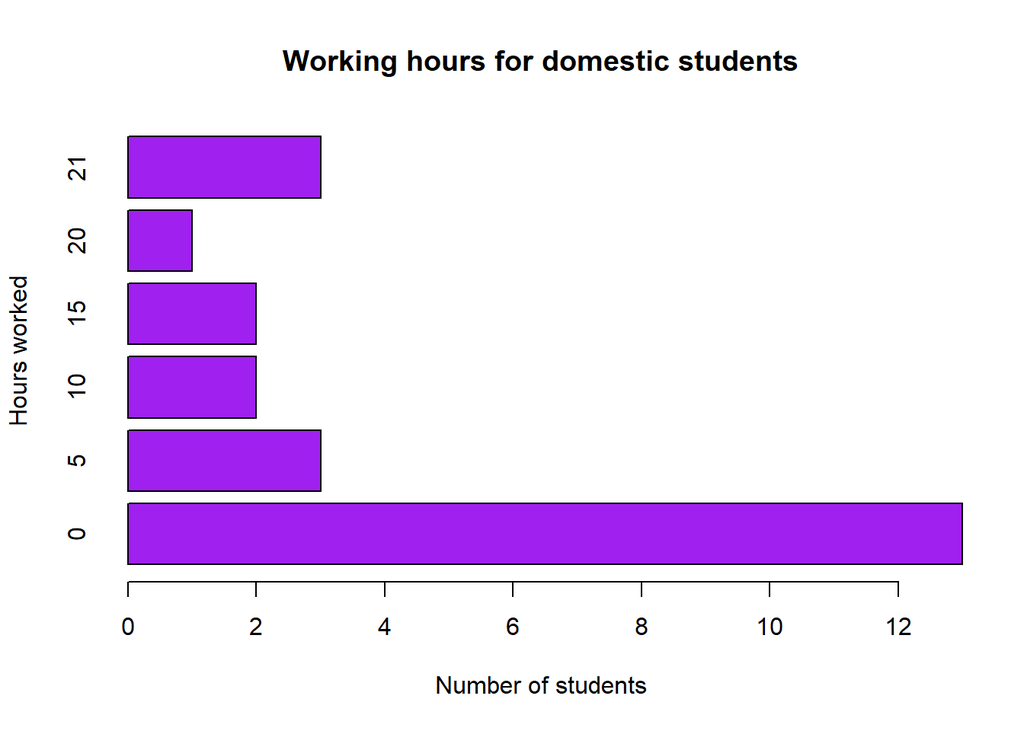

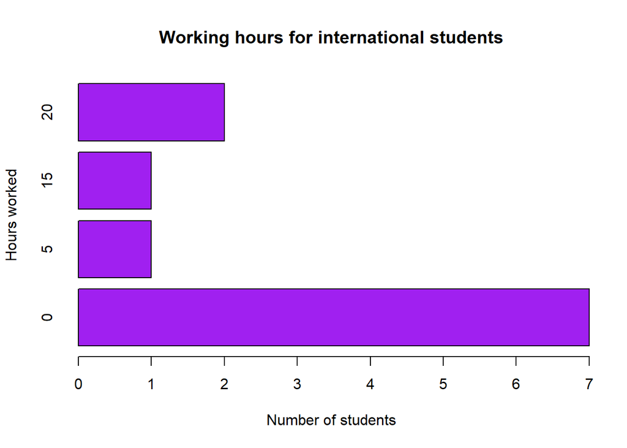

From the sample data, most domestic students are **currently unemployed**. The next highest being 5 hours a week and 21 hours a week. This trend continues with *international students* as most are unemployed as well.

### 2.2.2

Has student working hours increased or decreased due to COVID-19?

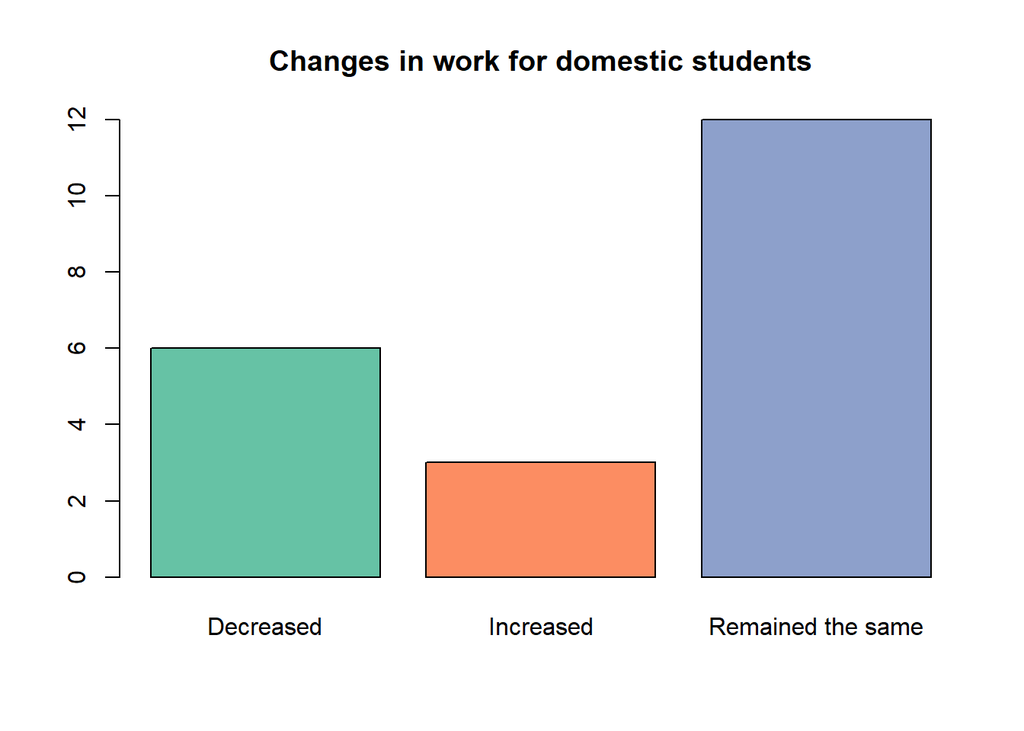

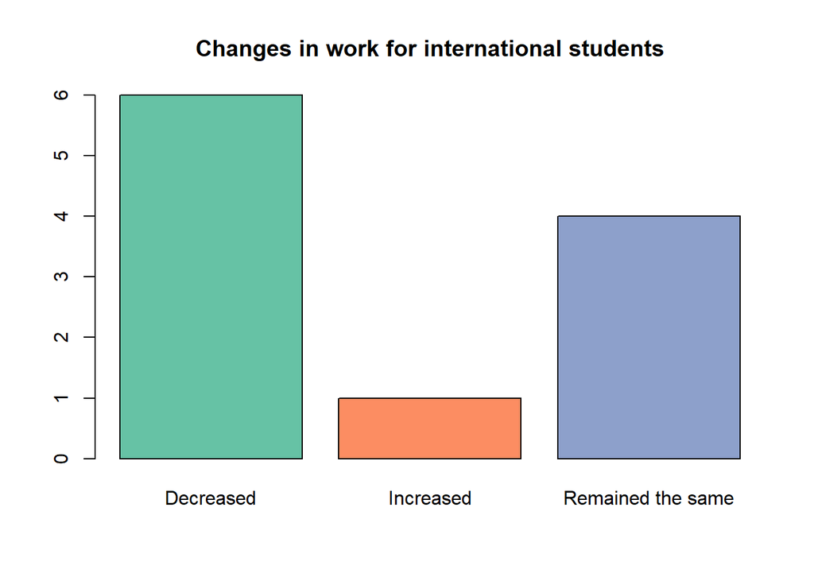

A higher proportion of international students have reported **decreased work hours** in comparison to domestic students which can suggest a *higher financial burden* experienced by international students.

### 2.2.3

Does the financial support received due to COVID-19 differ between domestic and international students?

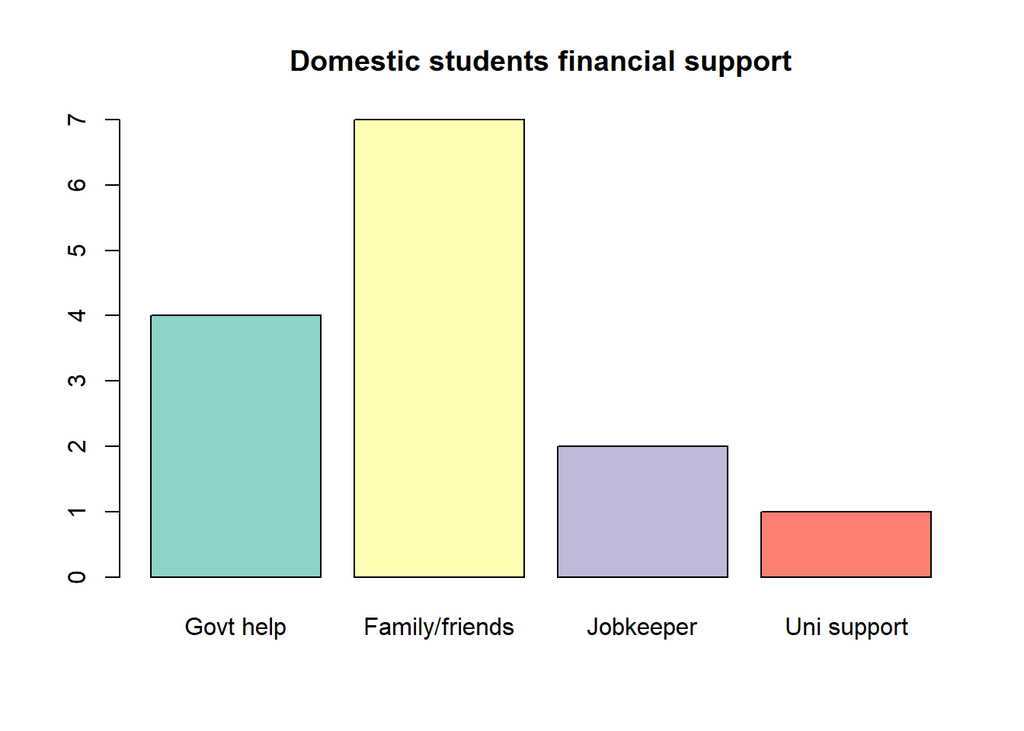

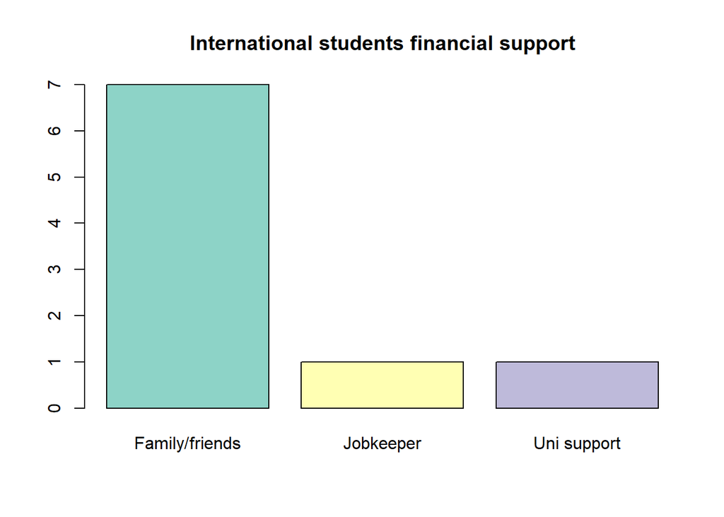

For both domestic and international students, **financial support from family and friends** is the main form of aid received.

COVID-19 supplements is also a widely received support option with domestic students. However, it is not present with international students as other countries/governments *do not* provide such aid.

### 2.2.4

Is there a relationship between the hours worked and the number of hours studied during COVID-19?

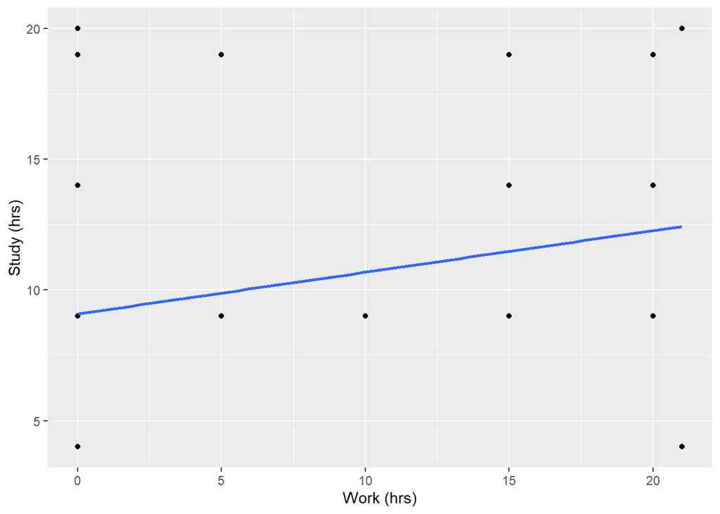

```
##
## Call:
## lm(formula = study ~ work)
##
## Residuals:
##     Min      1Q  Median      3Q     Max
## -8.4341 -5.0872 -0.0872  2.1237 10.9128
##
## Coefficients:
##             Estimate Std. Error t value Pr(>|t|)
## (Intercept)   9.0872     1.1428   7.951 3.59e-09 ***
## work          0.1594     0.1123   1.419    0.165
## ---
## Signif. codes:  0 '***' 0.001 '**' 0.01 '*' 0.05 '.' 0.1 ' ' 1
##
## Residual standard error: 5.418 on 33 degrees of freedom
## Multiple R-squared:  0.0575, Adjusted R-squared:  0.02894
## F-statistic: 2.013 on 1 and 33 DF,  p-value: 0.1653
```

```
## [1] 0.2397875
```

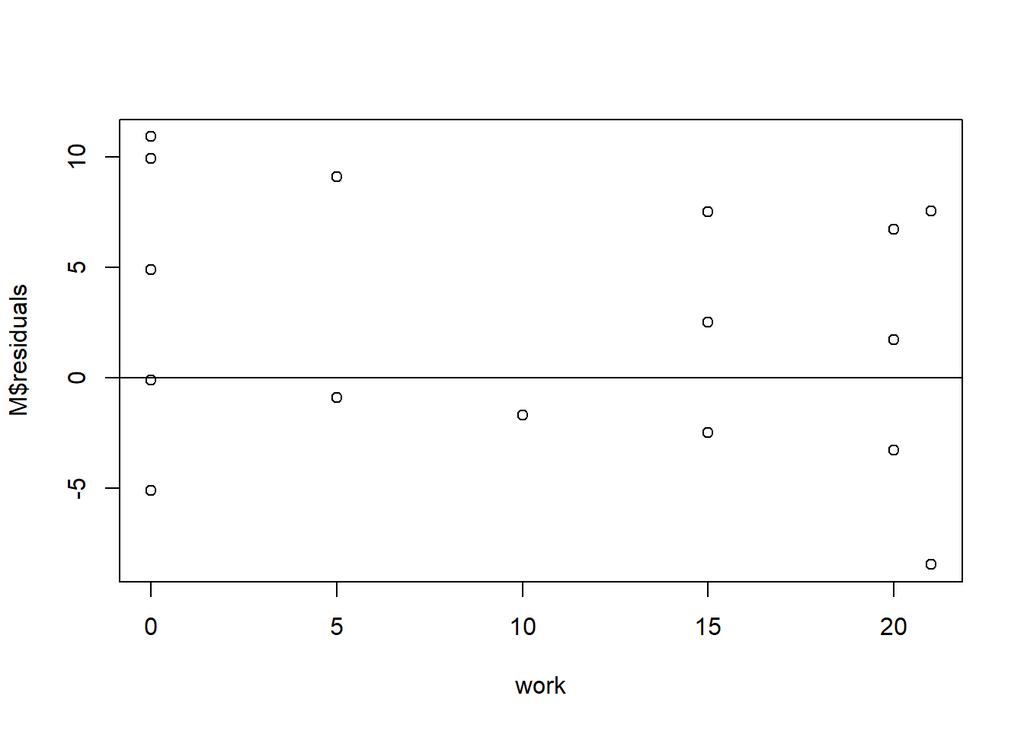

The data appears to be heteroscedastic hence why a linear model is not suitable but this might also be due to the lack of participants. Surprisingly, despite the weak relationship it suggests that the **more hours worked correlated with higher hours of study** which also highlights that time may not be the only major contributing factor to student studies.

Other factors like work ethic, motivation and lifestyles and one’s studyload may influence the hrs of study undertaken by students.

### 2.2.5

Have the challenges of COVID-19 towards the quality of education received contributed to domestic and international student’s consideration of deferring their studies?

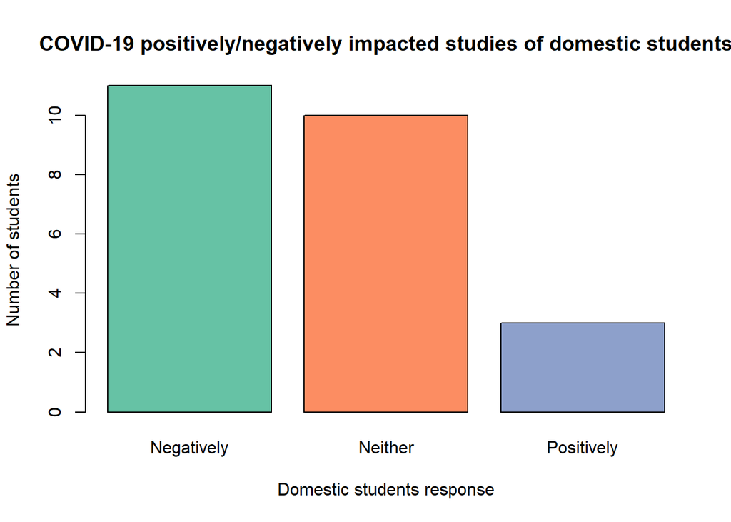

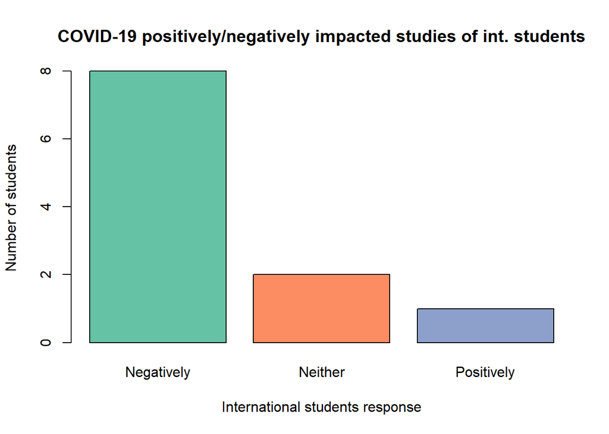

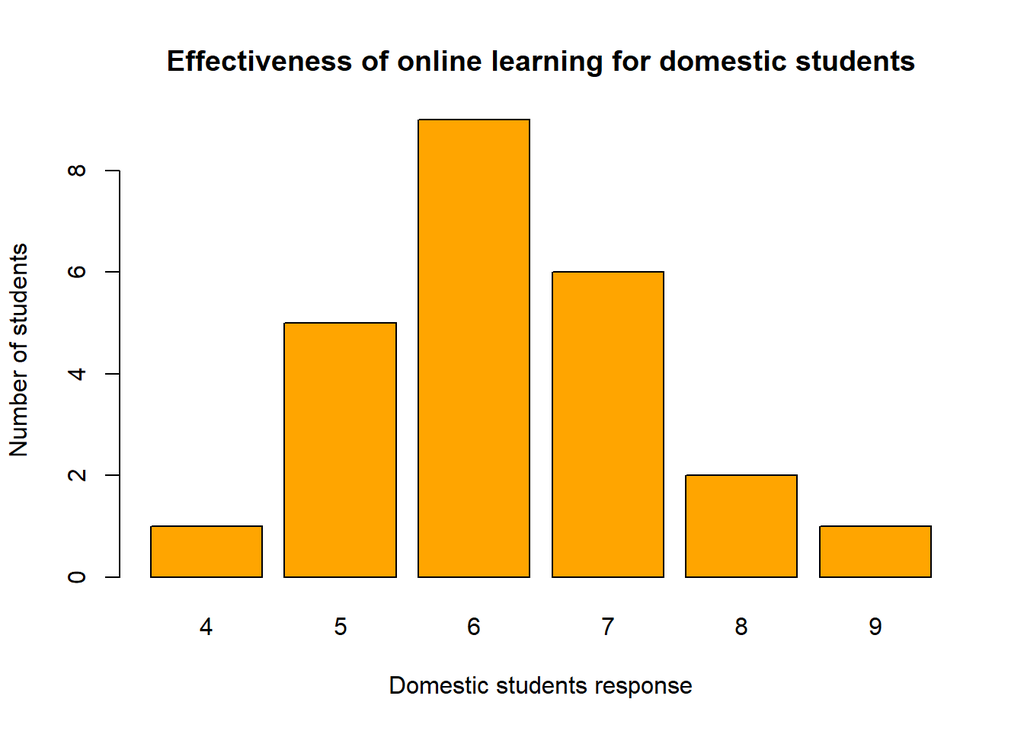

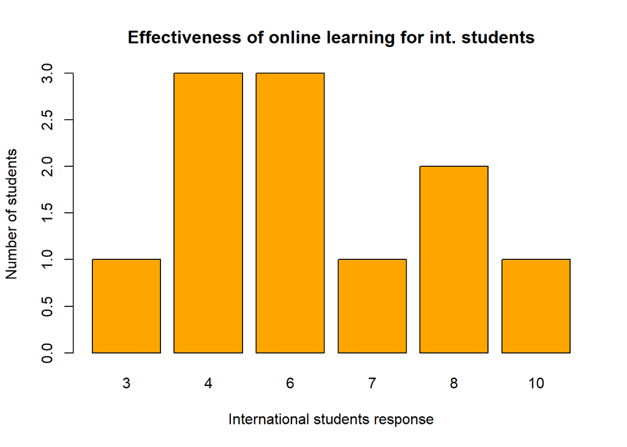

This could indicate that **COVID-19 has not necessarily contributed directly** to students deferring studies as there are some who do prefer online learning or feel a positive impact on their studies with their current circumstances.

### 2.2.6

Do international students consider deferring studies more than domestic students? If so, how come?

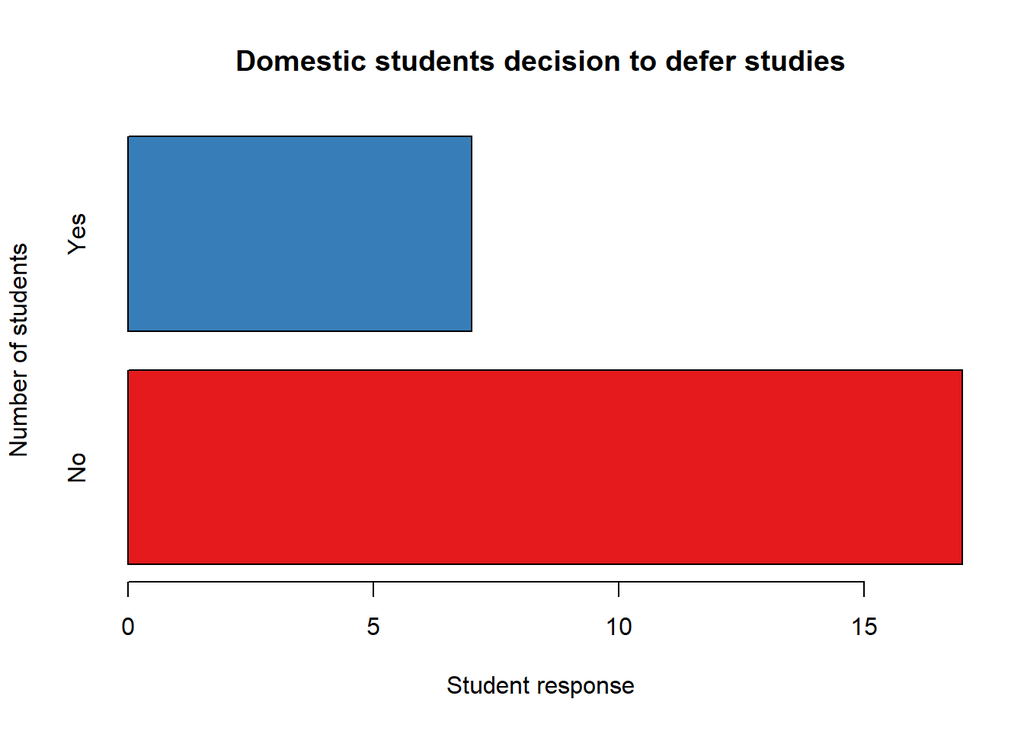

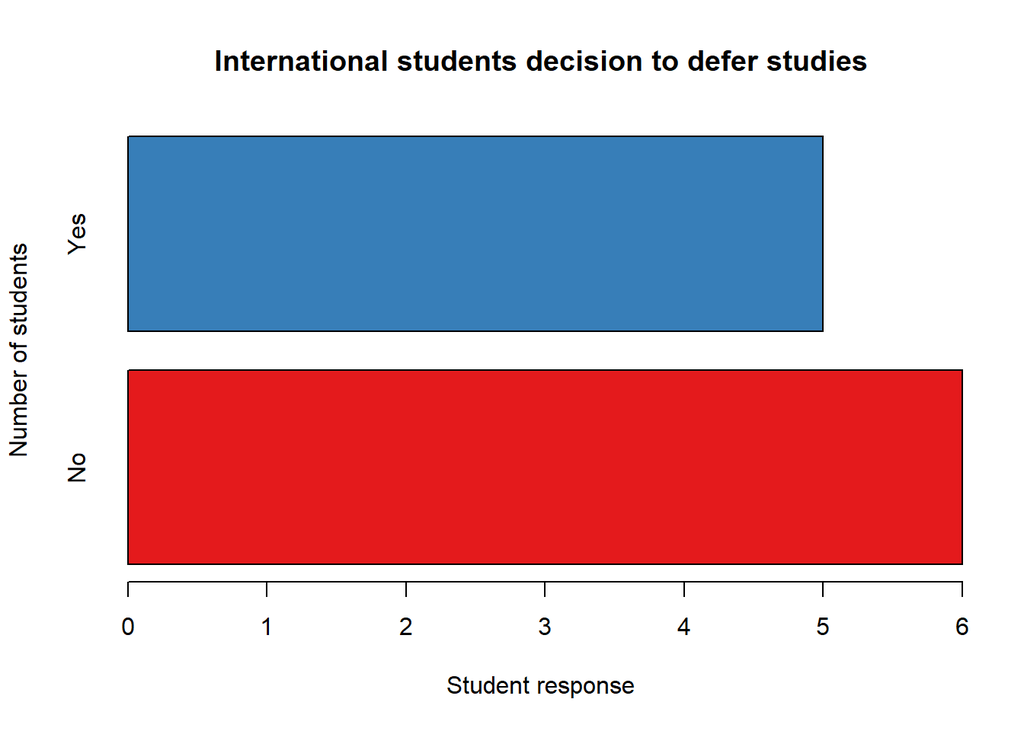

## 2.3 Related Articles

International students have been reported to experience financial hardships during COVID-19 with many experiencing job cuts especially with being excluded from government help programs (Purtill, 2020). This added financial stress with a predominantly online learning environment has been shown to negatively impact student studies (Morris et al., 2020).

## 2.4 References

- Morris, A., Hastings, C., Wilson, S., Mitchell, E., Ramia, G., & Overgaard, C. (2020). The Experience of International Students Before and During COVID-19. Retrieved from Analysis & Policy Observatory: https://bit.ly/3kljJrO
- Purtill, J. (2020). ‘It has really f*****d me over’: The impact of COVID on young hospitality. Retrieved October 21, 2020, from https://www.abc.net.au/triplej/programs/hack/covid-19-coronavirus-pandemic-hit-young-hospitality-workers-hard/12799238

## 2.5 Acknowledgments

Team consists of Ella, Keane, Leo and Yunhan. Group met on the 28th of September, around 1:30pm (GMT+11) via Facebook.

Ella contributed in the making of the survey through Google Forms and analysing results.

Keane coded the report in RStudio and assisted in making the survey.

Both Leo and Yunhan contributed by suggesting possible questions for the survey and distributing it to peers for data collection.